# Montserrat Forest Bird Monitoring - Annual Summary

Department of Environment / RSPB

The forests on Montserrat are home for two globally threatened forest bird species, the endemic Montserrat Oriole and the Forest Thrush. Since 1999 the Department of Environment and the RSPB have counted the forest birds in the Center Hills along 11 survey routes at least once per year at the beginning of the birds’ breeding season in April.

### Forest bird monitoring in April and May 2025

In 2025, we conducted point counts of all forest species between 07 Apr and 02 May and completed a total of 264 independent counts at 88 points in the forest, with three independent counts at each point.

During each of the three survey rounds, we counted between 1294 and 1614 birds across all 88 points. The observed number per species for the selected 12 most common species in each of the three survey rounds is shown in Table 1.

Table 1: Observed number of forest birds in the Centre Hills of Montserrat in April and May 2025 during three independent survey rounds.

| Species | Total N in round 1 | Total N in round 2 | Total N in round 3 |
| --- | --- | --- | --- |
| PEARLY-EYED THRASHER | 367 | 456 | 458 |
| BANANAQUIT | 256 | 272 | 249 |
| SCALY-BREASTED THRASHER | 164 | 165 | 162 |
| SCALY-NAPED PIGEON | 138 | 206 | 247 |
| FOREST THRUSH | 128 | 176 | 207 |
| MONTSERRAT ORIOLE | 72 | 64 | 68 |
| ANTILLEAN CRESTED HUMMINGBIRD | 56 | 60 | 72 |
| PURPLE-THROATED CARIB | 42 | 65 | 56 |
| BROWN TREMBLER | 38 | 30 | 49 |
| BRIDLED QUAIL-DOVE | 32 | 48 | 46 |
| GREEN-THROATED CARIB | 1 | 0 | 0 |
| CARIBBEAN ELAENIA | 0 | 0 | 0 |

### Estimate of forest bird trends on Montserrat since 2011

Since the survey design with three repeated counts at each point was introduced in 2011, we use binomial mixture models to estimate the abundance of birds around all survey points, and the long term trend across years. The three repeated visits allow us to estimate what proportion of birds were not seen during the surveys, so that the estimated number is less affected by temporal changes in weather or bird calling activity, and the estimated trend should not be affected by differences between observation conditions in different years.

The estimated population sizes for all species and years are shown in Figure 1, and the long-term trend estimates for all species are shown in Table 2.

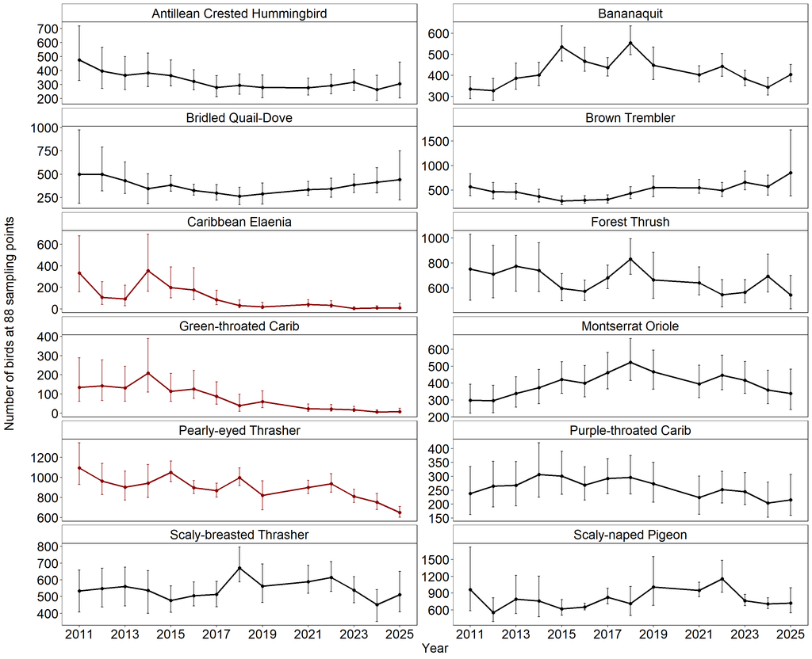

*Figure 1: Estimated abundance of 12 forest bird species around 88 point count locations in the Center Hills of Montserrat since 2011. Species shown with green lines are increasing, species with red lines are decreasing, and species with black lines are stable (or have no discernible trend direction).*

Table 2: Estimated trend of 12 forest bird species surveyed between 2011 and 2025 in the Centre Hills of Montserrat. The model fits a linear (trend) and a quadratic (trend2) term on the population trend - this allows population change to be non-linear. If trend2 is positive, then the population went through a depression and is recovering, if trend2 is negative, the population initially increased but is now decreasing again. Note that ‘model fit’ is assessed via a Bayesian p-value, which indicates poor model fit at values close to 0 and close to 1.

| Species | Direction | Trend estimate | Model fit |
| --- | --- | --- | --- |
| Antillean Crested Hummingbird | stable | -0.13 (-0.27 - 0) | 0.00 |
|  | flat | 0.09 (-0.07 - 0.28) | 0.00 |
| Bananaquit | stable | 0.02 (-0.07 - 0.11) | 0.00 |
|  | concave | -0.14 (-0.24 - -0.03) | 0.00 |
| Bridled Quail-Dove | stable | -0.04 (-0.23 - 0.16) | 0.15 |
|  | flat | 0.19 (-0.06 - 0.46) | 0.15 |
| Caribbean Elaenia | decrease | -1.18 (-1.85 - -0.46) | 0.92 |
|  | flat | -0.29 (-0.96 - 0.35) | 0.92 |
| Forest Thrush | stable | -0.07 (-0.2 - 0.07) | 0.01 |
|  | flat | 0 (-0.16 - 0.14) | 0.01 |
| Green-throated Carib | decrease | -1.08 (-1.49 - -0.67) | 0.57 |
|  | flat | -0.38 (-0.85 - 0.09) | 0.57 |
| Montserrat Oriole | stable | 0.06 (-0.04 - 0.18) | 0.25 |
|  | concave | -0.17 (-0.28 - -0.04) | 0.25 |
| Pearly-eyed Thrasher | decrease | -0.1 (-0.19 - -0.02) | 0.00 |
|  | flat | -0.03 (-0.12 - 0.06) | 0.00 |
| Purple-throated Carib | stable | -0.07 (-0.21 - 0.08) | 0.00 |
|  | flat | -0.1 (-0.24 - 0.05) | 0.00 |
| Scaly-breasted Thrasher | stable | 0 (-0.1 - 0.1) | 0.00 |
|  | flat | -0.04 (-0.18 - 0.08) | 0.00 |
| Scaly-naped Pigeon | stable | 0.05 (-0.16 - 0.23) | 0.15 |
|  | flat | -0.02 (-0.23 - 0.21) | 0.15 |
| Brown Trembler | stable | 0.16 (-0.04 - 0.36) | 0.69 |
|  | convex | 0.22 (0 - 0.45) | 0.69 |